# This Notebook uses RSEM coutns

```r
library(repr)
options(repr.plot.width=7, repr.plot.height=7)
```

if (!requireNamespace("BiocManager", quietly = TRUE)) install.packages("BiocManager") BiocManager::install("tmm")

```r
library(tidyverse)
library(WriteXLS)
```

```r
library(DESeq2)
library(apeglm)
library(EnhancedVolcano)
library(ggplot2)
library(pheatmap)
```

```r
setwd('/gpfs/commons/groups/sanjana_lab/cdai/TFscreen/')
```

```r
dir(pattern='*.csv', path = 'data/H2HY7BGXC/rsem_results/')
```

1. 'rsem_counts.csv'

2. 'rsem_TPM.csv'

```r
cnts <- read.csv(file = 'data/H2HY7BGXC/rsem_results/rsem_counts.csv')
```

```r
cnts %>% head
```

A data.frame: 6 × 24

| gene_id <fct> | S01 <dbl> | S02 <dbl> | S03 <dbl> | S04 <dbl> | S05 <dbl> | S06 <dbl> | S07 <dbl> | S08 <dbl> | S09 <dbl> | ⋯ | S14 <dbl> | S15 <dbl> | S16 <dbl> | S17 <dbl> | S18 <dbl> | S19 <dbl> | S20 <dbl> | S21 <dbl> | S22 <dbl> | gene_name <fct> |
| --- | --- | --- | --- | --- | --- | --- | --- | --- | --- | --- | --- | --- | --- | --- | --- | --- | --- | --- | --- | --- |
| ENSG00000000003.14 | 817.0001 | 789.0001 | 757.0001 | 991.0001 | 1194.0001 | 1093.0001 | 739.0001 | 998.0001 | 1311.0001 | ⋯ | 1066.0001 | 1317.0001 | 1210.0001 | 1070.0001 | 1262.0001 | 1604.0001 | 1064.0001 | 175.0001 | 294.0001 | TSPAN6 |
| ENSG00000000005.6 | 19.0001 | 0.0001 | 11.0001 | 1.0001 | 0.0001 | 0.0001 | 0.0001 | 0.0001 | 0.0001 | ⋯ | 0.0001 | 0.0001 | 19.0001 | 0.0001 | 0.0001 | 0.0001 | 0.0001 | 0.0001 | 0.0001 | TNMD |
| ENSG00000000419.12 | 762.0001 | 746.0001 | 809.0001 | 516.0001 | 340.0001 | 597.0001 | 390.0001 | 513.0001 | 515.0001 | ⋯ | 326.0001 | 455.0001 | 530.0001 | 151.0001 | 853.0001 | 797.0001 | 345.0001 | 378.0001 | 255.0001 | DPM1 |
| ENSG00000000457.14 | 20.5201 | 49.0501 | 28.5701 | 56.7901 | 65.6601 | 40.8801 | 138.0001 | 168.3501 | 70.4101 | ⋯ | 34.4501 | 23.7301 | 0.0001 | 205.0001 | 0.0001 | 129.1501 | 82.9401 | 46.0801 | 111.0001 | SCYL3 |
| ENSG00000000460.17 | 114.4801 | 160.9501 | 153.4301 | 101.2101 | 148.3401 | 94.1201 | 0.0001 | 70.6501 | 107.5901 | ⋯ | 142.5501 | 413.2701 | 194.0001 | 211.0001 | 146.0001 | 114.8501 | 118.0601 | 54.9201 | 0.0001 | C1orf112 |
| ENSG00000000938.13 | 0.0001 | 0.0001 | 0.0001 | 0.0001 | 0.0001 | 0.0001 | 0.0001 | 0.0001 | 0.0001 | ⋯ | 0.0001 | 0.0001 | 0.0001 | 0.0001 | 0.0001 | 0.0001 | 0.0001 | 0.0001 | 0.0001 | FGR |

```r
cnts[,2:23] <- apply(cnts[,2:23],2, as.integer) # convert rsem floating data to integer
```

```r
cnts <- cnts %>% column_to_rownames('gene_id')
```

```r
str(cnts)
head(cnts)
```

```
'data.frame':	60662 obs. of  23 variables:
 $ S01      : int  817 19 762 20 114 0 0 229 146 168 ...
 $ S02      : int  789 0 746 49 160 0 0 190 177 145 ...
 $ S03      : int  757 11 809 28 153 0 0 277 202 72 ...
 $ S04      : int  991 1 516 56 101 0 0 229 39 148 ...
 $ S05      : int  1194 0 340 65 148 0 0 313 131 292 ...
 $ S06      : int  1093 0 597 40 94 0 0 546 78 202 ...
 $ S07      : int  739 0 390 138 0 0 0 80 54 166 ...
 $ S08      : int  998 0 513 168 70 0 1 209 32 224 ...
 $ S09      : int  1311 0 515 70 107 0 2 297 103 186 ...
 $ S10      : int  558 0 191 26 42 0 0 119 35 80 ...
 $ S11      : int  775 10 407 73 83 0 0 219 130 193 ...
 $ S12      : int  1346 14 482 111 51 0 0 267 81 207 ...
 $ S13      : int  1228 25 770 90 136 0 0 403 298 398 ...
 $ S14      : int  1066 0 326 34 142 0 0 102 188 184 ...
 $ S15      : int  1317 0 455 23 413 0 7 159 237 285 ...
 $ S16      : int  1210 19 530 0 194 0 0 184 178 129 ...
 $ S17      : int  1070 0 151 205 211 0 2 201 0 632 ...
 $ S18      : int  1262 0 853 0 146 0 0 206 101 247 ...
 $ S19      : int  1604 0 797 129 114 0 0 372 103 264 ...
 $ S20      : int  1064 0 345 82 118 0 0 211 239 312 ...
 $ S21      : int  175 0 378 46 54 0 1 174 0 295 ...
 $ S22      : int  294 0 255 111 0 0 0 136 85 133 ...
 $ gene_name: Factor w/ 59087 levels "A1BG","A1BG-AS1",..: 56274 55506 27106 51433 23392 28996 24837 29441 29754 40808 ...
```

A data.frame: 6 × 23

|  | S01 <int> | S02 <int> | S03 <int> | S04 <int> | S05 <int> | S06 <int> | S07 <int> | S08 <int> | S09 <int> | S10 <int> | ⋯ | S14 <int> | S15 <int> | S16 <int> | S17 <int> | S18 <int> | S19 <int> | S20 <int> | S21 <int> | S22 <int> | gene_name <fct> |
| --- | --- | --- | --- | --- | --- | --- | --- | --- | --- | --- | --- | --- | --- | --- | --- | --- | --- | --- | --- | --- | --- |
| ENSG00000000003.14 | 817 | 789 | 757 | 991 | 1194 | 1093 | 739 | 998 | 1311 | 558 | ⋯ | 1066 | 1317 | 1210 | 1070 | 1262 | 1604 | 1064 | 175 | 294 | TSPAN6 |
| ENSG00000000005.6 | 19 | 0 | 11 | 1 | 0 | 0 | 0 | 0 | 0 | 0 | ⋯ | 0 | 0 | 19 | 0 | 0 | 0 | 0 | 0 | 0 | TNMD |
| ENSG00000000419.12 | 762 | 746 | 809 | 516 | 340 | 597 | 390 | 513 | 515 | 191 | ⋯ | 326 | 455 | 530 | 151 | 853 | 797 | 345 | 378 | 255 | DPM1 |
| ENSG00000000457.14 | 20 | 49 | 28 | 56 | 65 | 40 | 138 | 168 | 70 | 26 | ⋯ | 34 | 23 | 0 | 205 | 0 | 129 | 82 | 46 | 111 | SCYL3 |
| ENSG00000000460.17 | 114 | 160 | 153 | 101 | 148 | 94 | 0 | 70 | 107 | 42 | ⋯ | 142 | 413 | 194 | 211 | 146 | 114 | 118 | 54 | 0 | C1orf112 |
| ENSG00000000938.13 | 0 | 0 | 0 | 0 | 0 | 0 | 0 | 0 | 0 | 0 | ⋯ | 0 | 0 | 0 | 0 | 0 | 0 | 0 | 0 | 0 | FGR |

# Preliminary

```r
mean_cnts <- apply(cnts[,1:22], 1, mean)
var_cnts <- apply(cnts[,1:22], 1, var)
df <- data.frame(mean_cnts, var_cnts)
```

```r
?scale_y_log10
```

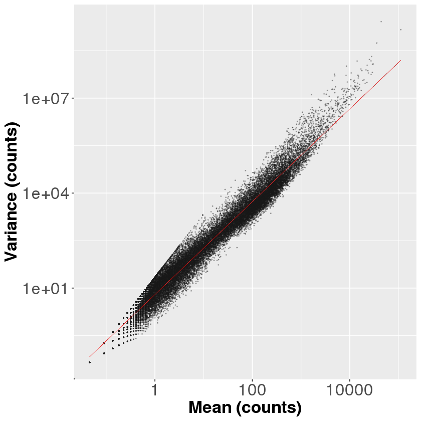

```r
ggplot(df) + geom_point(aes(x=mean_cnts, y=var_cnts), size=.2, alpha=0.3, color="grey10") +
             geom_smooth(aes(x=mean_cnts, y=var_cnts),method = 'glm', size=.2, color='red', alpha=1) +
             labs(y="Variance (counts)", x="Mean (counts)") +
             scale_y_log10() + scale_x_log10() +
             theme(axis.text.x = element_text(size = 20), axis.title.x = element_text(size=20, face='bold'),
                   axis.text.y = element_text(size = 20), axis.title.y = element_text(size=20, face='bold'))
```

```r
cnts %>% head(2)
```

A data.frame: 2 × 23

|  | S01 <int> | S02 <int> | S03 <int> | S04 <int> | S05 <int> | S06 <int> | S07 <int> | S08 <int> | S09 <int> | S10 <int> | ⋯ | S14 <int> | S15 <int> | S16 <int> | S17 <int> | S18 <int> | S19 <int> | S20 <int> | S21 <int> | S22 <int> | gene_name <fct> |
| --- | --- | --- | --- | --- | --- | --- | --- | --- | --- | --- | --- | --- | --- | --- | --- | --- | --- | --- | --- | --- | --- |
| ENSG00000000003.14 | 817 | 789 | 757 | 991 | 1194 | 1093 | 739 | 998 | 1311 | 558 | ⋯ | 1066 | 1317 | 1210 | 1070 | 1262 | 1604 | 1064 | 175 | 294 | TSPAN6 |
| ENSG00000000005.6 | 19 | 0 | 11 | 1 | 0 | 0 | 0 | 0 | 0 | 0 | ⋯ | 0 | 0 | 19 | 0 | 0 | 0 | 0 | 0 | 0 | TNMD |

Check correlation between replicates

```r
library(repr)
options(repr.plot.width=14, repr.plot.height=10)
```

WT.ES 1, 2 108.ES 3, 4 112.ES 5, 6 WT.Day4 7,8 108.Day4 9, 10 112.Day4 11, 12

```r
cnts_tpm <- read.csv(file = 'data/H2HY7BGXC/rsem_results/rsem_TPM.csv')
```

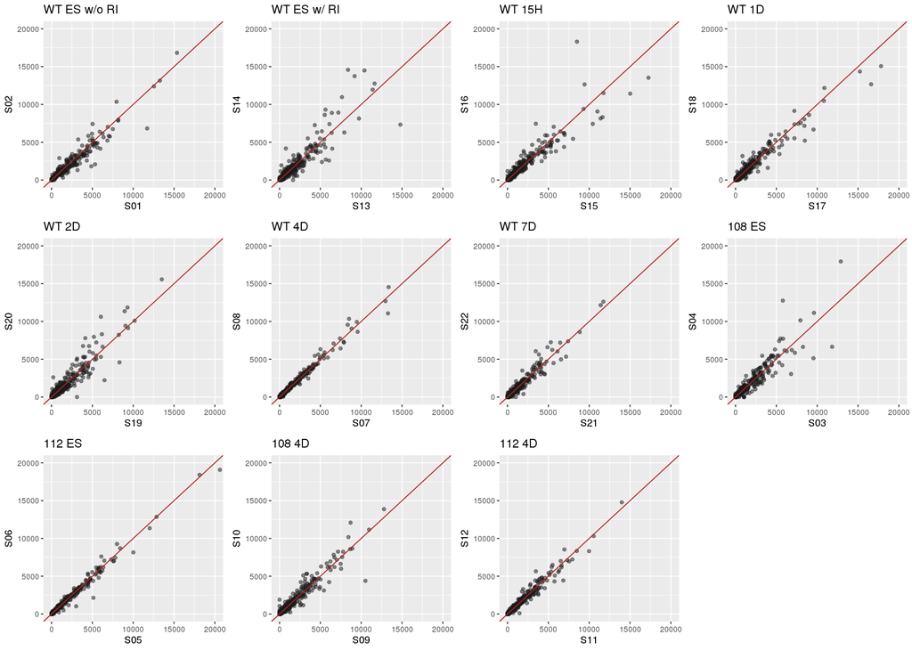

```r
gg <- ggplot(cnts_tpm)
p1 <- gg + geom_point(aes(x=S01, y=S02), color='grey10', alpha=0.5) + geom_abline(slope = 1, color='firebrick') + coord_cartesian(xlim = c(0,2e04), ylim = c(0,2e04)) + labs(title = "WT ES w/o RI")
p2 <- gg + geom_point(aes(x=S13, y=S14), color='grey10', alpha=0.5) + geom_abline(slope = 1, color='firebrick') + coord_cartesian(xlim = c(0,2e04), ylim = c(0,2e04)) + labs(title = "WT ES w/ RI")
p3 <- gg + geom_point(aes(x=S15, y=S16), color='grey10', alpha=0.5) + geom_abline(slope = 1, color='firebrick') + coord_cartesian(xlim = c(0,2e04), ylim = c(0,2e04)) + labs(title = "WT 15H")
p4 <- gg + geom_point(aes(x=S17, y=S18), color='grey10', alpha=0.5) + geom_abline(slope = 1, color='firebrick') + coord_cartesian(xlim = c(0,2e04), ylim = c(0,2e04)) + labs(title = "WT 1D")
p5 <- gg + geom_point(aes(x=S19, y=S20), color='grey10', alpha=0.5) + geom_abline(slope = 1, color='firebrick') + coord_cartesian(xlim = c(0,2e04), ylim = c(0,2e04)) + labs(title = "WT 2D")
p6 <- gg + geom_point(aes(x=S07, y=S08), color='grey10', alpha=0.5) + geom_abline(slope = 1, color='firebrick') + coord_cartesian(xlim = c(0,2e04), ylim = c(0,2e04)) + labs(title = "WT 4D")
p7 <- gg + geom_point(aes(x=S21, y=S22), color='grey10', alpha=0.5) + geom_abline(slope = 1, color='firebrick') + coord_cartesian(xlim = c(0,2e04), ylim = c(0,2e04)) + labs(title = "WT 7D")
p8 <- gg + geom_point(aes(x=S03, y=S04), color='grey10', alpha=0.5) + geom_abline(slope = 1, color='firebrick') + coord_cartesian(xlim = c(0,2e04), ylim = c(0,2e04)) + labs(title = "108 ES")
p9 <- gg + geom_point(aes(x=S05, y=S06), color='grey10', alpha=0.5) + geom_abline(slope = 1, color='firebrick') + coord_cartesian(xlim = c(0,2e04), ylim = c(0,2e04)) + labs(title = "112 ES")
p10 <- gg + geom_point(aes(x=S09, y=S10), color='grey10', alpha=0.5) + geom_abline(slope = 1, color='firebrick') + coord_cartesian(xlim = c(0,2e04), ylim = c(0,2e04)) + labs(title = "108 4D")
p11 <- gg + geom_point(aes(x=S11, y=S12), color='grey10', alpha=0.5) + geom_abline(slope = 1, color='firebrick') + coord_cartesian(xlim = c(0,2e04), ylim = c(0,2e04)) + labs(title = "112 4D")


gridExtra::grid.arrange(p1, p2, p3, p4, p5, p6, p7,p8,p9,p10,p11, ncol=4)
```

# ACT III

**WT with devlopment:**

| Condition | Sample |
| --- | --- |
| ES w/o RI | 1, 2 |
| ES w/ RI | 13, 14 |
| +DOX 15h | 15, 16 |
| +DOX Day1 | 17, 18 |
| +DOX Day2 | 19, 20 |
| +DOX Day4 | 7, 8 |
| +DOX Day7 | 21, 22 |

contrasts: ES, 15H, 1D, 2D, 4D, 7D

```r
cols3 <- c('S01', 'S02','S13','S14','S15','S16','S17','S18','S19','S20','S07','S08','S21','S22') # relevent samples
cnts3 <- cnts[,cols3]
```

```r
colnames(cnts3)
head(cnts3)
```

1. 'S01'

2. 'S02'

3. 'S13'

4. 'S14'

5. 'S15'

6. 'S16'

7. 'S17'

8. 'S18'

9. 'S19'

10. 'S20'

11. 'S07'

12. 'S08'

13. 'S21'

14. 'S22'

A data.frame: 6 × 14

|  | S01 <int> | S02 <int> | S13 <int> | S14 <int> | S15 <int> | S16 <int> | S17 <int> | S18 <int> | S19 <int> | S20 <int> | S07 <int> | S08 <int> | S21 <int> | S22 <int> |
| --- | --- | --- | --- | --- | --- | --- | --- | --- | --- | --- | --- | --- | --- | --- |
| ENSG00000000003.14 | 817 | 789 | 1228 | 1066 | 1317 | 1210 | 1070 | 1262 | 1604 | 1064 | 739 | 998 | 175 | 294 |
| ENSG00000000005.6 | 19 | 0 | 25 | 0 | 0 | 19 | 0 | 0 | 0 | 0 | 0 | 0 | 0 | 0 |
| ENSG00000000419.12 | 762 | 746 | 770 | 326 | 455 | 530 | 151 | 853 | 797 | 345 | 390 | 513 | 378 | 255 |
| ENSG00000000457.14 | 20 | 49 | 90 | 34 | 23 | 0 | 205 | 0 | 129 | 82 | 138 | 168 | 46 | 111 |
| ENSG00000000460.17 | 114 | 160 | 136 | 142 | 413 | 194 | 211 | 146 | 114 | 118 | 0 | 70 | 54 | 0 |
| ENSG00000000938.13 | 0 | 0 | 0 | 0 | 0 | 0 | 0 | 0 | 0 | 0 | 0 | 0 | 0 | 0 |

```r
gtf_lookup = read.csv('/gpfs/commons/groups/sanjana_lab/cdai/ref_genome/gencode.v31.primary_assembly.annotation.gene_idTOgene_name.txt') #gencode gene_id to gene_name lookup
```

```r
gene_ids3 = rownames_to_column(cnts3,'gene_id')[,1:2]
gtf_lookup$gene_id <- as.character(gtf_lookup$gene_id)
gene_names3 = left_join(gene_ids3, gtf_lookup, 'gene_id') %>% pull(gene_name) %>% as.character
```

```r
gene_names3 %>% str
```

```
 chr [1:60662] "TSPAN6" "TNMD" "DPM1" "SCYL3" "C1orf112" "FGR" "CFH" ...
```

```r
coldata3 <- read.csv('conditions_group3.csv')
```

```r
cnts3 %>% head
```

A data.frame: 6 × 14

|  | S01 <int> | S02 <int> | S13 <int> | S14 <int> | S15 <int> | S16 <int> | S17 <int> | S18 <int> | S19 <int> | S20 <int> | S07 <int> | S08 <int> | S21 <int> | S22 <int> |
| --- | --- | --- | --- | --- | --- | --- | --- | --- | --- | --- | --- | --- | --- | --- |
| ENSG00000000003.14 | 817 | 789 | 1228 | 1066 | 1317 | 1210 | 1070 | 1262 | 1604 | 1064 | 739 | 998 | 175 | 294 |
| ENSG00000000005.6 | 19 | 0 | 25 | 0 | 0 | 19 | 0 | 0 | 0 | 0 | 0 | 0 | 0 | 0 |
| ENSG00000000419.12 | 762 | 746 | 770 | 326 | 455 | 530 | 151 | 853 | 797 | 345 | 390 | 513 | 378 | 255 |
| ENSG00000000457.14 | 20 | 49 | 90 | 34 | 23 | 0 | 205 | 0 | 129 | 82 | 138 | 168 | 46 | 111 |
| ENSG00000000460.17 | 114 | 160 | 136 | 142 | 413 | 194 | 211 | 146 | 114 | 118 | 0 | 70 | 54 | 0 |
| ENSG00000000938.13 | 0 | 0 | 0 | 0 | 0 | 0 | 0 | 0 | 0 | 0 | 0 | 0 | 0 | 0 |

```r
coldata3
```

A data.frame: 14 × 2

| condition <fct> | group <fct> |
| --- | --- |
| ES_wo_RI | ES |
| ES_wo_RI | ES |
| ES_w_RI | ES |
| ES_w_RI | ES |
| DOX_15H | DOX_15H |
| DOX_15H | DOX_15H |
| DOX_1D | DOX_1D |
| DOX_1D | DOX_1D |
| DOX_2D | DOX_2D |
| DOX_2D | DOX_2D |
| DOX_4D | DOX_4D |
| DOX_4D | DOX_4D |
| DOX_7D | DOX_7D |
| DOX_7D | DOX_7D |

```r
dds3 <- DESeqDataSetFromMatrix(countData = cnts3, colData = coldata3, design = ~ group)
```

```r
all(rownames(dds3) == gene_ids3$gene_id) # make sure all gene_ids are the same as the gene ids in dds
```

TRUE

```r
mcols(dds3) <- cbind(mcols(dds3), 'gene_name' = gene_names3) # adding gene_names to counts dds
```

```r
keep3 <- rowSums(counts(dds3)) >= 10 # pre-analysis filter to remove very low read count genes
dds3 <- dds3[keep3,]
```

```r
dim(dds3)
```

1. 25069

2. 14

```r
# specify factor level (instead of letting R to decide)
dds3$condition <- factor(dds3$condition, levels = unique(as.vector(coldata3$condition)))
dds3$group <- factor(dds3$group, levels = unique(as.vector(coldata3$group)))
```

```r
counts(dds3) %>% head()
```

A matrix: 6 × 14 of type int

|  | S01 | S02 | S13 | S14 | S15 | S16 | S17 | S18 | S19 | S20 | S07 | S08 | S21 | S22 |
| --- | --- | --- | --- | --- | --- | --- | --- | --- | --- | --- | --- | --- | --- | --- |
| ENSG00000000003.14 | 817 | 789 | 1228 | 1066 | 1317 | 1210 | 1070 | 1262 | 1604 | 1064 | 739 | 998 | 175 | 294 |
| ENSG00000000005.6 | 19 | 0 | 25 | 0 | 0 | 19 | 0 | 0 | 0 | 0 | 0 | 0 | 0 | 0 |
| ENSG00000000419.12 | 762 | 746 | 770 | 326 | 455 | 530 | 151 | 853 | 797 | 345 | 390 | 513 | 378 | 255 |
| ENSG00000000457.14 | 20 | 49 | 90 | 34 | 23 | 0 | 205 | 0 | 129 | 82 | 138 | 168 | 46 | 111 |
| ENSG00000000460.17 | 114 | 160 | 136 | 142 | 413 | 194 | 211 | 146 | 114 | 118 | 0 | 70 | 54 | 0 |
| ENSG00000000971.15 | 0 | 0 | 0 | 0 | 7 | 0 | 2 | 0 | 0 | 0 | 0 | 1 | 1 | 0 |

```r
dds3 <- DESeq(dds3) # build model
```

```r
resultsNames(dds3) # model coefficients
```

1. 'Intercept'

2. 'group_DOX_15H_vs_ES'

3. 'group_DOX_1D_vs_ES'

4. 'group_DOX_2D_vs_ES'

5. 'group_DOX_4D_vs_ES'

6. 'group_DOX_7D_vs_ES'

### Volcano plots

#### 15H vs. WT

```r
res3a <- results(dds3, contrast = c('group','DOX_15H','ES')) # modelling ES vs. +DOX

# add gene_name to result
if (all(rownames(res3a) == rownames(dds3))) {
    res3a.df <- cbind(res3a, 'gene_name' = mcols(dds3)$gene_name) %>% as.data.frame %>% rownames_to_column('gene_id') %>% filter(!is.na(padj))
}  else {
    print("Rownames don't match!")
}
```

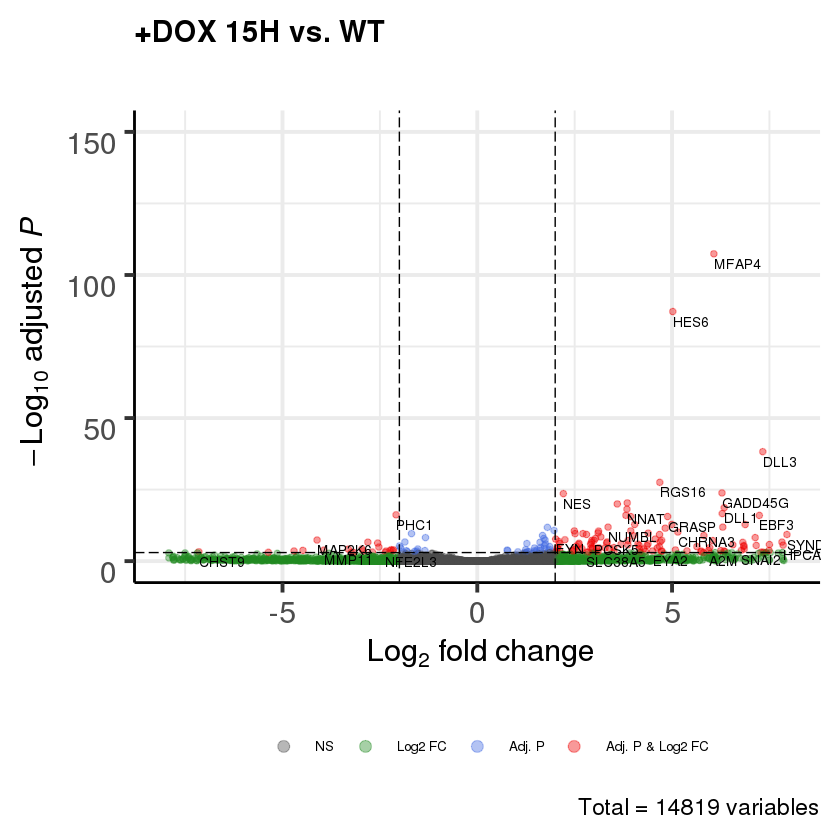

```r
EnhancedVolcano(res3a.df, lab = res3a.df$gene_name, x='log2FoldChange',y='padj', xlim=c(-8,8), ylim=c(0,150),
                xlab = bquote(~Log[2]~ 'fold change'), ylab= bquote(~-Log[10]~adjusted~italic(P)),
                legend=c('NS','Log2 FC','Adj. P', 'Adj. P & Log2 FC'),legendPosition='bottom', legendLabSize = 8,
                legendIconSize = 3.0, title = "+DOX 15H vs. WT", subtitle="", pCutoff = 0.001, FCcutoff = 2,
                transcriptPointSize = 1.5, transcriptLabSize = 3.0, colAlpha = .4)
# selectLab = c('FHL3', 'STRAG') to only label key transcripts
```

#### 1D vs. WT

```r
res3b <- results(dds3, contrast = c('group','DOX_1D','ES'))

# add gene_name to result
if (all(rownames(res3b) == rownames(dds3))) {
    res3b.df <- cbind(res3b, 'gene_name' = mcols(dds3)$gene_name) %>% as.data.frame %>% rownames_to_column('gene_id') %>% filter(!is.na(padj))
}  else {
    print("Rownames don't match!")
}
```

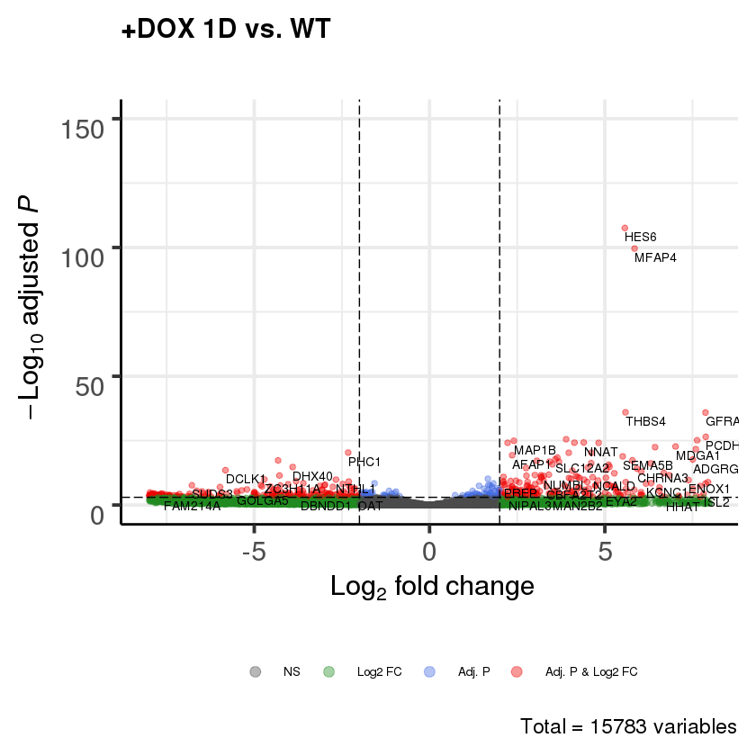

```r
EnhancedVolcano(res3b.df, lab = res3b.df$gene_name, x='log2FoldChange',y='padj', xlim=c(-8,8), ylim=c(0,150),
                xlab = bquote(~Log[2]~ 'fold change'), ylab= bquote(~-Log[10]~adjusted~italic(P)),
                legend=c('NS','Log2 FC','Adj. P', 'Adj. P & Log2 FC'),legendPosition='bottom', legendLabSize = 8,
                legendIconSize = 3.0, title = "+DOX 1D vs. WT", subtitle="", pCutoff = 0.001, FCcutoff = 2,
                transcriptPointSize = 1.5, transcriptLabSize = 3.0, colAlpha = .4)
# selectLab = c('FHL3', 'STRAG') to only label key transcripts
```

#### 2D vs. WT

```r
res3c <- results(dds3, contrast = c('group','DOX_2D','ES'))

# add gene_name to result
if (all(rownames(res3c) == rownames(dds3))) {
    res3c.df <- cbind(res3c, 'gene_name' = mcols(dds3)$gene_name) %>% as.data.frame %>% rownames_to_column('gene_id') %>% filter(!is.na(padj))
}  else {
    print("Rownames don't match!")
}
```

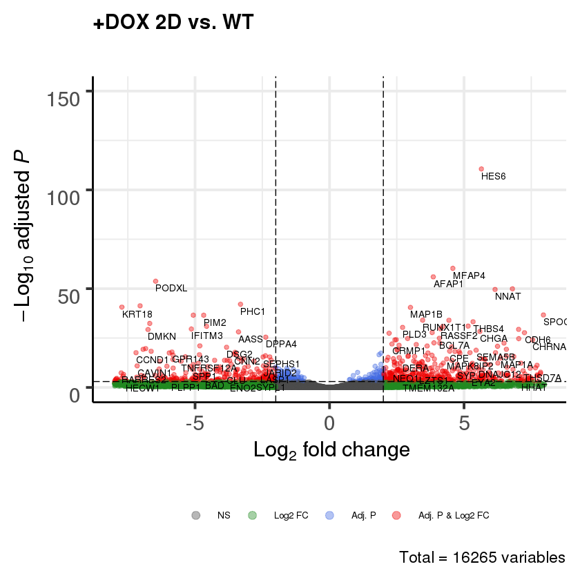

```r
EnhancedVolcano(res3c.df, lab = res3c.df$gene_name, x='log2FoldChange',y='padj', xlim=c(-8,8), ylim=c(0,150),
                xlab = bquote(~Log[2]~ 'fold change'), ylab= bquote(~-Log[10]~adjusted~italic(P)),
                legend=c('NS','Log2 FC','Adj. P', 'Adj. P & Log2 FC'),legendPosition='bottom', legendLabSize = 8,
                legendIconSize = 3.0, title = "+DOX 2D vs. WT", subtitle="", pCutoff = 0.001, FCcutoff = 2,
                transcriptPointSize = 1.5, transcriptLabSize = 3.0, colAlpha = .4)
# selectLab = c('FHL3', 'STRAG') to only label key transcripts
```

#### 4D vs. WT

```r
res3d <- results(dds3, contrast = c('group','DOX_4D','ES'))

# add gene_name to result
if (all(rownames(res3c) == rownames(dds3))) {
    res3d.df <- cbind(res3d, 'gene_name' = mcols(dds3)$gene_name) %>% as.data.frame %>% rownames_to_column('gene_id') %>% filter(!is.na(padj))
}  else {
    print("Rownames don't match!")
}
```

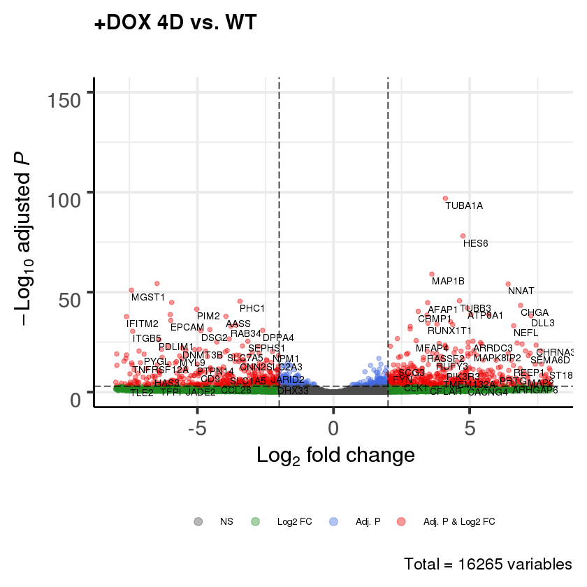

```r
EnhancedVolcano(res3d.df, lab = res3d.df$gene_name, x='log2FoldChange',y='padj', xlim=c(-8,8), ylim=c(0,150),
                xlab = bquote(~Log[2]~ 'fold change'), ylab= bquote(~-Log[10]~adjusted~italic(P)),
                legend=c('NS','Log2 FC','Adj. P', 'Adj. P & Log2 FC'),legendPosition='bottom', legendLabSize = 8,
                legendIconSize = 3.0, title = "+DOX 4D vs. WT", subtitle="", pCutoff = 0.001, FCcutoff = 2,
                transcriptPointSize = 1.5, transcriptLabSize = 3.0, colAlpha = .4)
# selectLab = c('FHL3', 'STRAG') to only label key transcripts
```

#### 7D vs. WT

```r
res3e <- results(dds3, contrast = c('group','DOX_7D','ES'))

# add gene_name to result
if (all(rownames(res3c) == rownames(dds3))) {
    res3e.df <- cbind(res3e, 'gene_name' = mcols(dds3)$gene_name) %>% as.data.frame %>% rownames_to_column('gene_id') %>% filter(!is.na(padj))
}  else {
    print("Rownames don't match!")
}
```

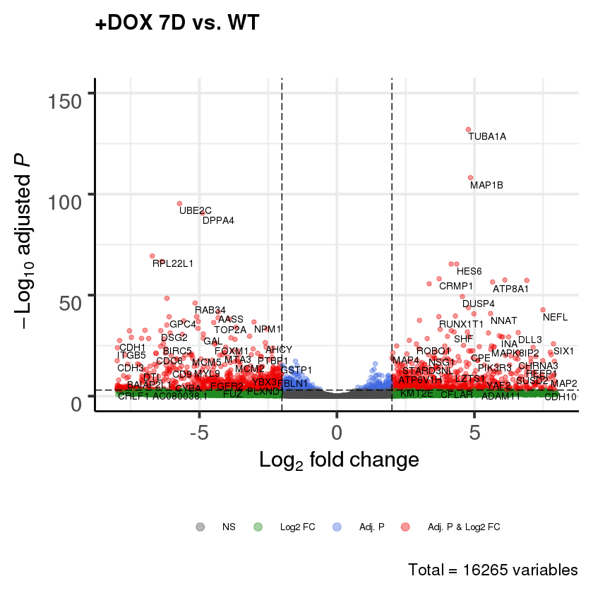

```r
EnhancedVolcano(res3e.df, lab = res3d.df$gene_name, x='log2FoldChange',y='padj', xlim=c(-8,8), ylim=c(0,150),
                xlab = bquote(~Log[2]~ 'fold change'), ylab= bquote(~-Log[10]~adjusted~italic(P)),
                legend=c('NS','Log2 FC','Adj. P', 'Adj. P & Log2 FC'),legendPosition='bottom', legendLabSize = 8,
                legendIconSize = 3.0, title = "+DOX 7D vs. WT", subtitle="", pCutoff = 0.001, FCcutoff = 2,
                transcriptPointSize = 1.5, transcriptLabSize = 3.0, colAlpha = .4)
# selectLab = c('FHL3', 'STRAG') to only label key transcripts
```

### Get genes at each temporal point

```r
sig_genes_3a <- res3a.df %>% filter(padj < 0.001) %>% pull('gene_name') %>% unique %>% as.character
sig_genes_3b <- res3b.df %>% filter(padj < 0.001) %>% pull('gene_name') %>% unique %>% as.character
sig_genes_3c <- res3c.df %>% filter(padj < 0.001) %>% pull('gene_name') %>% unique %>% as.character
sig_genes_3d <- res3d.df %>% filter(padj < 0.001) %>% pull('gene_name') %>% unique %>% as.character
sig_genes_3e <- res3e.df %>% filter(padj < 0.001) %>% pull('gene_name') %>% unique %>% as.character
```

```r
res3a.df %>% head
```

A data.frame: 6 × 8

| gene_id <chr> | baseMean <dbl> | log2FoldChange <dbl> | lfcSE <dbl> | stat <dbl> | pvalue <dbl> | padj <dbl> | gene_name <chr> |
| --- | --- | --- | --- | --- | --- | --- | --- |
| ENSG00000000003.14 | 879.99726 | 0.35963730 | 0.2802046 | 1.28348123 | 0.1993235 | 0.7861680 | TSPAN6 |
| ENSG00000000419.12 | 479.11925 | -0.39933924 | 0.5769459 | -0.69216065 | 0.4888364 | 0.9529152 | DPM1 |
| ENSG00000000457.14 | 73.28362 | -2.05638600 | 1.4155296 | -1.45273264 | 0.1462980 | 0.7070020 | SCYL3 |
| ENSG00000000460.17 | 122.47691 | 1.09960742 | 1.2292140 | 0.89456141 | 0.3710216 | 0.9093266 | C1orf112 |
| ENSG00000001036.13 | 188.50378 | -0.39018072 | 0.5053694 | -0.77207029 | 0.4400728 | 0.9344654 | FUCA2 |
| ENSG00000001084.13 | 117.22656 | 0.03973555 | 1.3256272 | 0.02997491 | 0.9760871 | 1.0000000 | GCLC |

##### Number of genes significant in each tempral profile

```r
sig_genes_3a %>% length
sig_genes_3b %>% length
sig_genes_3c %>% length
sig_genes_3d %>% length
sig_genes_3e %>% length
```

205

631

1130

1555

2329

##### Build a matrix that shows how significant genes show up at different time point.

| . | 15H | 1D | 2D | 4D | 7D |
| --- | --- | --- | --- | --- | --- |
| Gene1 | log2FC | log2FC | log2FC | log2FC | log2FC |
| Gene2 |  | log2FC | log2FC | log2FC | log2FC |

... GeneN| | | |log2FC|log2FC

```r
is.numeric(c(1,2,5))
```

TRUE

```r
length(c(1,1,1,1,1)==5) & is.numeric(c(1,1,1,1,1))
```

TRUE

```r
# A function to convert a vector of 5 binary numbers (represented in integer) into an integer.
# This esentially represents/flags gene expression time profile.
# e.g. c(1,1,1,1,1) => 31, c(0,0,1,0,0) => 8
bit.like.to.int <- function(c) {
    if (length(c) == 5 & is.numeric(c)){
        return(c[1]*2^4 + c[2]*2^3 + c[3]*2^2 + c[4]*2^1 + c[5]*2^0)
    }
    else {
        print("Vector must be numeric with a length of 5!")
    }
}

# DESeq2 results from each time point, combined into a list
res.all.times <- list(res3a.df, res3b.df, res3c.df, res3d.df, res3e.df)

# first get all significant gene_ids from all 5 time point
sig.geneID.all.times <- c()
fdr.cutoff <- 0.001
for (df in res.all.times) {
    geneID.temp <- df %>% filter(padj < fdr.cutoff) %>% pull(gene_id) %>% as.character
    sig.geneID.all.times <- c(sig.geneID.all.times, geneID.temp)
}
sig.geneID.all.times <- unique(sig.geneID.all.times) # significant gene_id from all 5 time points

# create a expression table with Log2FC at all 5 time points. The rows are genes that are significant at any timepoint.
# Value of NA means the gene is not significant at the given time point

#make a df of gene_id
expr.tbl <- sig.geneID.all.times %>% as.data.frame %>% rename('.'='gene_id') %>% mutate_at(vars(gene_id), as.character)

#create a list of log2FC for all the genes listed in expr.tbl at each time point
FC.all.times <- c()
for (df in res.all.times) {
    x <- expr.tbl %>% left_join(df[df$padj < fdr.cutoff, c('gene_id', 'log2FoldChange')], c('gene_id')) %>%
        select(log2FoldChange) %>% pull(log2FoldChange)
    FC.all.times <- c(FC.all.times, list(x)) # log2FC for the gene_id
}

#add log2FC at each time point as a column, then left join to add gene name
expr.tbl <- expr.tbl %>% add_column('15H' = FC.all.times[[1]]) %>% add_column('1D' = FC.all.times[[2]]) %>%
             add_column('2D' = FC.all.times[[3]]) %>% add_column('4D' = FC.all.times[[4]]) %>%
             add_column('7D' = FC.all.times[[5]]) %>% left_join(gtf_lookup, 'gene_id')


# create a logic matrix where 1: this gene is significant at this time point, and 0: not
logic.matrix <- apply(expr.tbl[,c(2:6)], MARGIN = 2, function(x) {!is.na(x)}) %>% as.data.frame %>%
        mutate_all(funs(as.integer))

# expression time profile flag. e.g. a number of 7 represents this gene is activated from D2 through D7, while 1 means only activated on D7
expr.flags <- c()
for (i in 1:dim(logic.matrix)[1]) {
    x <- logic.matrix[i,] %>% as.numeric # convert each row e.g.[1,0,0,0,0] into a numeric vector of 5 elements, eg.c(1,0,0,0,0)
    x <- bit.like.to.int(x) # calculate bit value (represented in int, eg. 00100 = 8)
    expr.flags <- c(expr.flags, x)
}

expr.tbl <- cbind(expr.tbl, expr.flag=expr.flags) # add expression flags
expr.tbl <- expr.tbl[,c(1,7:8,2:6)]
```

```r
expr.tbl %>% head
expr.tbl %>% dim
```

A data.frame: 6 × 8

| gene_id <chr> | gene_name <fct> | expr.flag <dbl> | 15H <dbl> | 1D <dbl> | 2D <dbl> | 4D <dbl> | 7D <dbl> |
| --- | --- | --- | --- | --- | --- | --- | --- |
| ENSG00000008083.14 | JARID2 | 23 | -1.547407 | NA | -2.458220 | -2.302813 | -1.377817 |
| ENSG00000008311.15 | AASS | 23 | -1.343921 | NA | -3.385232 | -3.952664 | -4.317948 |
| ENSG00000010810.17 | FYN | 23 | 2.012324 | NA | 1.891911 | 2.163458 | 2.729993 |
| ENSG00000017483.15 | SLC38A5 | 16 | 2.802791 | NA | NA | NA | NA |
| ENSG00000019549.13 | SNAI2 | 16 | 6.780420 | NA | NA | NA | NA |
| ENSG00000047648.23 | ARHGAP6 | 23 | 6.853818 | NA | 7.391730 | 6.556772 | 6.733971 |

1. 3140

2. 8

```r
expr.tbl %>% write.csv('FoldChangeByTimePoints.csv', row.names=F)
```

```r
expr.tbl %>% column_to_rownames('gene_id') %>% head
```

A data.frame: 6 × 7

|  | gene_name <fct> | expr.flag <dbl> | 15H <dbl> | 1D <dbl> | 2D <dbl> | 4D <dbl> | 7D <dbl> |
| --- | --- | --- | --- | --- | --- | --- | --- |
| ENSG00000008083.14 | JARID2 | 23 | -1.547407 | NA | -2.458220 | -2.302813 | -1.377817 |
| ENSG00000008311.15 | AASS | 23 | -1.343921 | NA | -3.385232 | -3.952664 | -4.317948 |
| ENSG00000010810.17 | FYN | 23 | 2.012324 | NA | 1.891911 | 2.163458 | 2.729993 |
| ENSG00000017483.15 | SLC38A5 | 16 | 2.802791 | NA | NA | NA | NA |
| ENSG00000019549.13 | SNAI2 | 16 | 6.780420 | NA | NA | NA | NA |
| ENSG00000047648.23 | ARHGAP6 | 23 | 6.853818 | NA | 7.391730 | 6.556772 | 6.733971 |

##### genes that are significant from 15H to 7D

```r
sig_genes_3a %>% intersect(sig_genes_3b) %>% intersect(sig_genes_3c) %>% intersect(sig_genes_3d) %>%
                 intersect(sig_genes_3e) %>% length
```

101

##### genes that become significant at Day 1 and continues to be significant at Day 2, Day 4 and Day 7

```r
sig_genes_3b %>% setdiff(sig_genes_3a) %>% intersect(sig_genes_3c) %>%
            intersect(sig_genes_3d) %>% intersect(sig_genes_3e) %>% length
```

113

##### genes that become significant at Day 2 and continues to be significant at Day 4 and Day 7

```r
sig_genes_3c %>% setdiff(unique(c(sig_genes_3a,sig_genes_3b))) %>% intersect(sig_genes_3d) %>% intersect(sig_genes_3e) %>% length
```

474

```r
sig_genes_3e %>% setdiff(unique(c(sig_genes_3a,sig_genes_3b, sig_genes_3c))) %>% intersect(sig_genes_3e) %>% length
```

1477

##### genes that are only significant at Day 7

```r
sig_genes_3e %>% setdiff(unique(c(sig_genes_3a,sig_genes_3b, sig_genes_3c, sig_genes_3d))) %>% length
```

999

## Zoom in on ~2000 screened TF

```r
#TF list
tflist <- read.csv('TFlist.csv') %>% pull(var = gene_name) %>% as.character
```

```r
tflist[1:5]
length(tflist)
```

1. 'AATF'

2. 'ABL1'

3. 'ABT1'

4. 'ABTB1'

5. 'ADNP'

1988

#### Result for each temporal stage

`gene`,`padj`,`log2FoldChange` for each temporal point (15H - 7D) for the 1988 TF genes.

Selection criteria:

- `padj` is not na
- `gene_name` in `tflist`

```r
res3a.df %>% tail
```

A data.frame: 6 × 8

|  | gene_id <chr> | baseMean <dbl> | log2FoldChange <dbl> | lfcSE <dbl> | stat <dbl> | pvalue <dbl> | padj <dbl> | gene_name <chr> |
| --- | --- | --- | --- | --- | --- | --- | --- | --- |
| 14814 | ENSG00000287967.1 | 14.407805 | -1.68171212 | 3.2414764 | -0.518810543 | 0.6038929 | 0.9755901 | AC004882.3 |
| 14815 | ENSG00000287978.1 | 9.793638 | 0.01092082 | 2.5125836 | 0.004346449 | 0.9965320 | 1.0000000 | AC245407.2 |
| 14816 | ENSG00000288044.1 | 17.713318 | -1.00026734 | 1.7573760 | -0.569182318 | 0.5692324 | 0.9702883 | AL096870.10 |
| 14817 | ENSG00000288045.1 | 12.535372 | -4.98875016 | 3.7579272 | -1.327527096 | 0.1843344 | 0.7637546 | AL352979.4 |
| 14818 | ENSG00000288066.1 | 61.033882 | -0.56560110 | 0.8250688 | -0.685519941 | 0.4930159 | 0.9530757 | AC097448.1 |
| 14819 | ENSG00000288075.1 | 14.274560 | -1.14332985 | 1.4848745 | -0.769984173 | 0.4413093 | 0.9346297 | AC108519.1 |

```r
# get DGE result, namely FC and padj, for each temproal point
res3a_tf <- res3a.df %>% filter((gene_name %in% tflist) & (!is.na(padj))) %>% select(gene_name, gene_id, padj, log2FoldChange)
res3b_tf <- res3b.df %>% filter((gene_name %in% tflist) & (!is.na(padj))) %>% select(gene_name, gene_id, padj, log2FoldChange)
res3c_tf <- res3c.df %>% filter((gene_name %in% tflist) & (!is.na(padj))) %>% select(gene_name, gene_id, padj, log2FoldChange)
res3d_tf <- res3d.df %>% filter((gene_name %in% tflist) & (!is.na(padj))) %>% select(gene_name, gene_id, padj, log2FoldChange)
res3e_tf <- res3e.df %>% filter((gene_name %in% tflist) & (!is.na(padj))) %>% select(gene_name, gene_id, padj, log2FoldChange)
```

```r
# Determine and annotate whether a TF screen listed gene is up or down regulated
fdr = 0.05
FC.threshold = 1.5
```

```r
res3a_tf <- res3a_tf %>% mutate(DGE=case_when(padj < fdr & log2FoldChange > FC.threshold ~ 'Up',
                                  padj < fdr & log2FoldChange < -FC.threshold ~ 'Down',
                                  padj < fdr & log2FoldChange >= -FC.threshold & log2FoldChange <= FC.threshold ~ 'No Change',
                                  padj >= fdr ~ 'No Change'))
res3b_tf <- res3b_tf %>% mutate(DGE=case_when(padj < fdr & log2FoldChange > FC.threshold ~ 'Up',
                                  padj < fdr & log2FoldChange < -FC.threshold ~ 'Down',
                                  padj < fdr & log2FoldChange >= -FC.threshold & log2FoldChange <= FC.threshold ~ 'No Change',
                                  padj >= fdr ~ 'No Change'))
res3c_tf <- res3c_tf %>% mutate(DGE=case_when(padj < fdr & log2FoldChange > FC.threshold ~ 'Up',
                                  padj < fdr & log2FoldChange < -FC.threshold ~ 'Down',
                                  padj < fdr & log2FoldChange >= -FC.threshold & log2FoldChange <= FC.threshold ~ 'No Change',
                                  padj >= fdr ~ 'No Change'))
res3d_tf <- res3d_tf %>% mutate(DGE=case_when(padj < fdr & log2FoldChange > FC.threshold ~ 'Up',
                                  padj < fdr & log2FoldChange < -FC.threshold ~ 'Down',
                                  padj < fdr & log2FoldChange >= -FC.threshold & log2FoldChange <= FC.threshold ~ 'No Change',
                                  padj >= fdr ~ 'No Change'))
res3e_tf <- res3e_tf %>% mutate(DGE=case_when(padj < fdr & log2FoldChange > FC.threshold ~ 'Up',
                                  padj < fdr & log2FoldChange < -FC.threshold ~ 'Down',
                                  padj < fdr & log2FoldChange >= -FC.threshold & log2FoldChange <= FC.threshold ~ 'No Change',
                                  padj >= fdr ~ 'No Change'))
```

```r
#Export to csv
res3a_tf %>% write.csv('TF_Screen_FC_Pval_15HvsES.csv', quote=F)
res3b_tf %>% write.csv('TF_Screen_FC_Pval_1DvsES.csv', quote=F)
res3c_tf %>% write.csv('TF_Screen_FC_Pval_2DvsES.csv', quote=F)
res3d_tf %>% write.csv('TF_Screen_FC_Pval_4DvsES.csv', quote=F)
res3e_tf %>% write.csv('TF_Screen_FC_Pval_7DvsES.csv', quote=F)
```

```r
res3a_tf %>% head
```

A data.frame: 6 × 5

| gene_name <chr> | gene_id <chr> | padj <dbl> | log2FoldChange <dbl> | DGE <chr> |
| --- | --- | --- | --- | --- |
| NFYA | ENSG00000001167.14 | 1.0000000 | -0.09616012 | No Change |
| UPF1 | ENSG00000005007.12 | 0.9747277 | 0.29124108 | No Change |
| POLR2J | ENSG00000005075.15 | 0.9751952 | -0.19372192 | No Change |
| CREBBP | ENSG00000005339.14 | 0.6539700 | 0.95113478 | No Change |
| ZNF195 | ENSG00000005801.18 | 0.9930787 | -0.16424237 | No Change |
| ZFX | ENSG00000005889.15 | 0.7627865 | 0.57844037 | No Change |

##### Summary plot for TF screen selected genes that are up/down regulated

```r
# summarize gene counts for TF screen selected genes
c <- c()
for (l in list(res3a_tf, res3b_tf, res3c_tf, res3d_tf, res3e_tf)) {
    gcount <- l %>% group_by(DGE) %>% summarize( "gene_count"=n()) %>% pull(gene_count) # get the count of genes
    c <- c(c,gcount)
}
tfs.bar.data <- data.frame(matrix(c, nrow=3))

colnames(tfs.bar.data) = c('15H', '1D', '2D', '4D','7D')
rownames(tfs.bar.data) = c('Down', 'No Change', 'Up')

tfs.bar.data <- tfs.bar.data %>% gather(condition, gene_counts) %>% add_column(DGE=rep(c('Down', 'No Change', 'Up'),5), .before=2)
```

```r
tfs.bar.data
```

A data.frame: 15 × 3

| condition <chr> | DGE <chr> | gene_counts <int> |
| --- | --- | --- |
| 15H | Down | 7 |
| 15H | No Change | 1256 |
| 15H | Up | 41 |
| 1D | Down | 101 |
| 1D | No Change | 1174 |
| 1D | Up | 68 |
| 2D | Down | 104 |
| 2D | No Change | 1150 |
| 2D | Up | 102 |
| 4D | Down | 122 |
| 4D | No Change | 1112 |
| 4D | Up | 122 |
| 7D | Down | 163 |
| 7D | No Change | 1019 |
| 7D | Up | 174 |

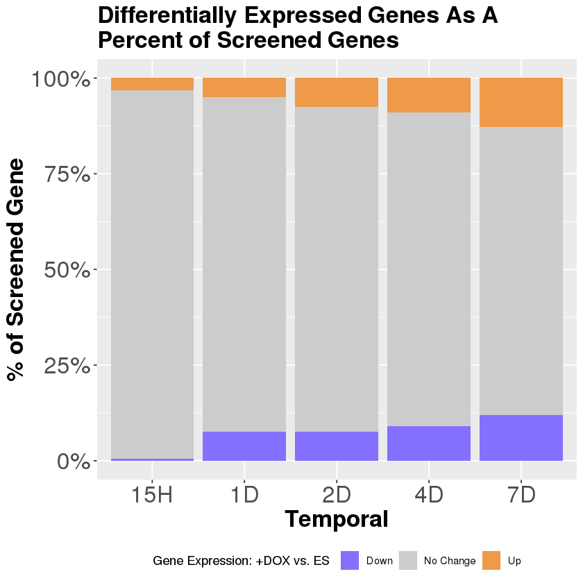

```r
ggplot(data = tfs.bar.data) + geom_bar(aes(x=condition, y=gene_counts, fill=DGE),position=position_fill(reverse = TRUE), stat="identity") +
            labs(y="% of Screened Gene", x="Temporal", title = "Differentially Expressed Genes As A \nPercent of Screened Genes") +
            scale_fill_manual(name='Gene Expression: +DOX vs. ES', values=c('lightslateblue', 'grey80', 'tan2')) +
            theme(axis.text = element_text(size = 20), axis.title=element_text(size=20, face='bold'), legend.position = "bottom",
                  plot.title = element_text(size = 20, face = 'bold')) +
            scale_y_continuous(labels = scales::percent)
```

##### Normalized counts of all TF screen genes, and plot heatmap

```r
cnts3_tf <- (counts(dds3, normalized=T) + 1e-06) %>% as.data.frame %>% rownames_to_column('gene_id') %>%
            inner_join(gtf_lookup, 'gene_id') %>% inner_join(data.frame(gene_name=tflist), 'gene_name')
cnts3_tf <- cnts3_tf[,c(1,16,2:15)]
cnts3_tf <- filter(cnts3_tf, gene_id != 'ENSG00000280987.4') # remove one gene_id from genes with multiple gene_ids
```

```r
cnts3_tf %>% write.csv('TF_ScreenSelectedNormalizedCounts.csv',row.names=F, quote=F)
```

ano3 <- as.data.frame(colData(dds3)[,c('condition','group')]) cnts3_tf[,c(2:16)] %>% column_to_rownames('gene_name') %>% as.matrix %>% pheatmap(cluster_rows = T, show_rownames = T, cluster_cols = F, annotation = ano3, fontsize=5, title = 'TF Selected in Screen', filename='TF_screen_selected.heatmap.pdf', width=8, height=66, silent=T)

```r
quadroot <- function (x) { # function to help decrease range of read counts. Easier for heatmap visulization
    return(x^(1/4))
}
```

```r
ano3 <- as.data.frame(colData(dds3)[,c('condition','group')]) #annotation for heatmap
```

##### Plot heatmaps of TF screened genes that are sigificant and pass FC threshold

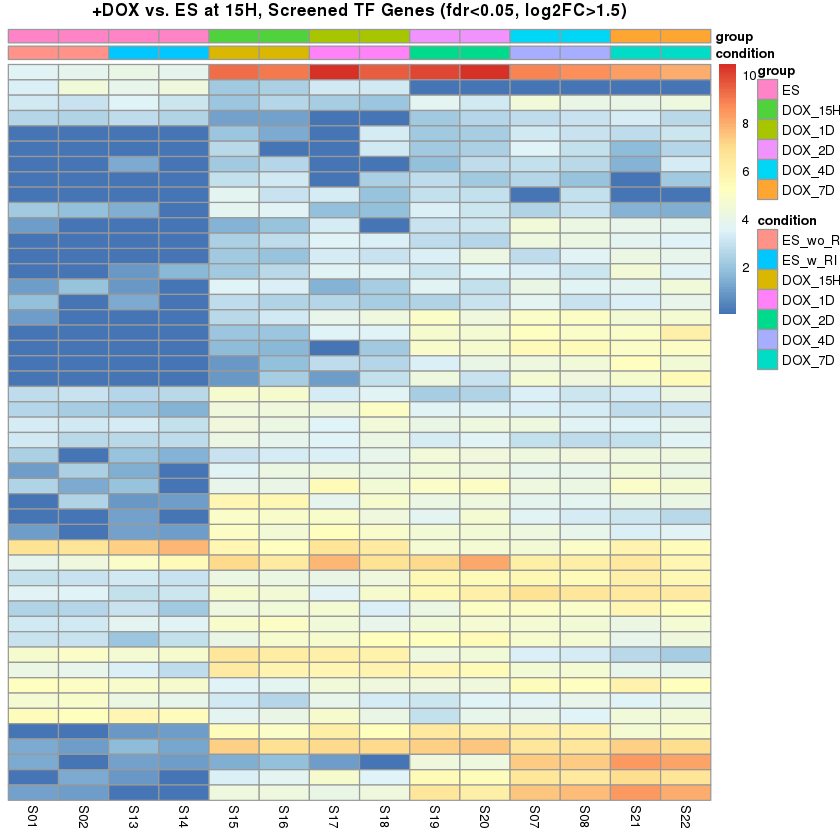

```r
tf.heatmap.genes.3a <- res3a_tf %>% filter(DGE != 'No Change' & padj < fdr & abs(log2FoldChange) > abs(FC.threshold)) %>% pull(gene_name) %>% as.character
cnts3_tf[,c(2:16)] %>% filter(gene_name %in% tf.heatmap.genes.3a) %>% column_to_rownames('gene_name') %>% mutate_all(quadroot) %>% as.matrix %>%
                pheatmap(cluster_rows = T, show_rownames = F, cluster_cols = F, annotation = ano3, fontsize=8, treeheight_row=0,
                main = paste0('+DOX vs. ES at 15H, Screened TF Genes (fdr<',fdr,', log2FC>',FC.threshold,')'))
```

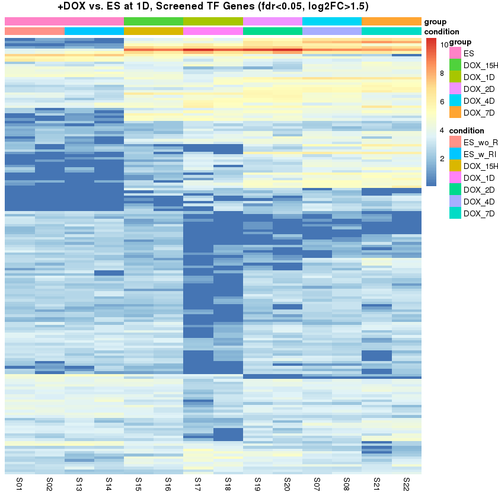

```r
tf.heatmap.genes.3b <- res3b_tf %>% filter(DGE != 'No Change' & padj < fdr & abs(log2FoldChange) > abs(FC.threshold)) %>% pull(gene_name) %>% as.character
cnts3_tf[,c(2:16)] %>% filter(gene_name %in% tf.heatmap.genes.3b) %>% column_to_rownames('gene_name') %>% mutate_all(quadroot) %>% as.matrix %>%
                pheatmap(cluster_rows = T, show_rownames = F, cluster_cols = F, annotation = ano3, fontsize=8, treeheight_row=0,
                main = paste0('+DOX vs. ES at 1D, Screened TF Genes (fdr<',fdr,', log2FC>',FC.threshold,')'))
```

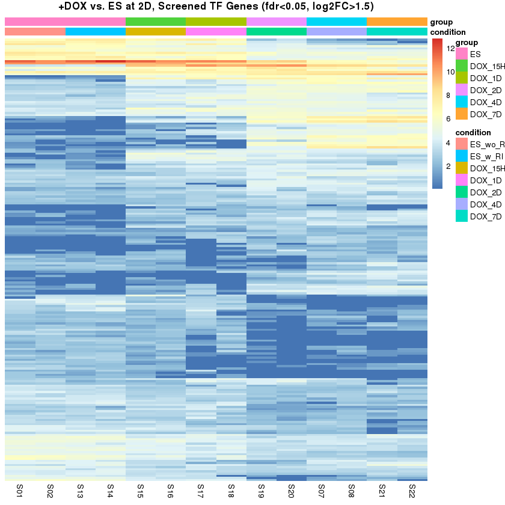

```r
tf.heatmap.genes.3c <- res3c_tf %>% filter(DGE != 'No Change' & padj < fdr & abs(log2FoldChange) > abs(FC.threshold)) %>% pull(gene_name) %>% as.character
cnts3_tf[,c(2:16)] %>% filter(gene_name %in% tf.heatmap.genes.3c) %>% column_to_rownames('gene_name') %>% mutate_all(quadroot) %>% as.matrix %>%
                pheatmap(cluster_rows = T, show_rownames = F, cluster_cols = F, annotation = ano3, fontsize=8, treeheight_row=0,
                main = paste0('+DOX vs. ES at 2D, Screened TF Genes (fdr<',fdr,', log2FC>',FC.threshold,')'))
```

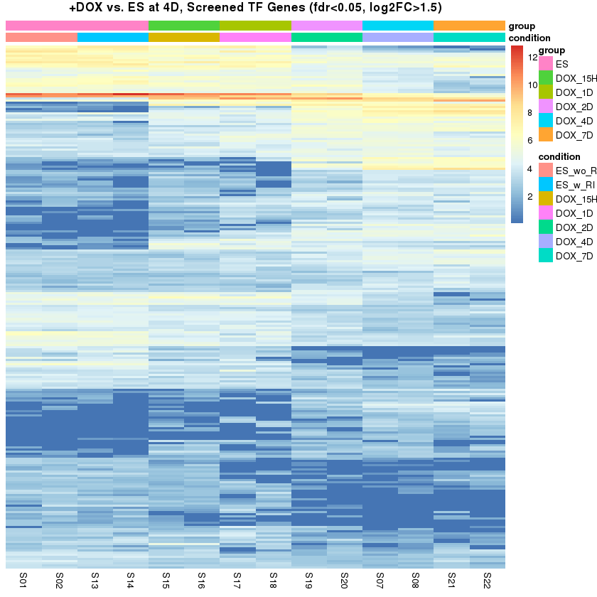

```r
tf.heatmap.genes.3d <- res3d_tf %>% filter(DGE != 'No Change' & padj < fdr & abs(log2FoldChange) > abs(FC.threshold)) %>% pull(gene_name) %>% as.character
cnts3_tf[,c(2:16)] %>% filter(gene_name %in% tf.heatmap.genes.3d) %>% column_to_rownames('gene_name') %>% mutate_all(quadroot) %>% as.matrix %>%
                pheatmap(cluster_rows = T, show_rownames = F, cluster_cols = F, annotation = ano3, fontsize=8, treeheight_row=0,
                main = paste0('+DOX vs. ES at 4D, Screened TF Genes (fdr<',fdr,', log2FC>',FC.threshold,')'))
```

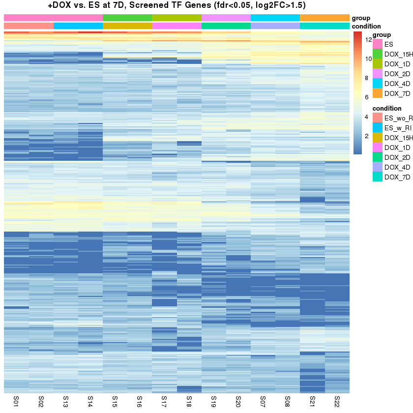

```r
tf.heatmap.genes.3e <- res3e_tf %>% filter(DGE != 'No Change' & padj < fdr & abs(log2FoldChange) > abs(FC.threshold)) %>% pull(gene_name) %>% as.character
cnts3_tf[,c(2:16)] %>% filter(gene_name %in% tf.heatmap.genes.3e) %>% column_to_rownames('gene_name') %>% mutate_all(quadroot) %>% as.matrix %>%
                pheatmap(cluster_rows = T, show_rownames = F, cluster_cols = F, annotation = ano3, fontsize=8, treeheight_row=0,
                main = paste0('+DOX vs. ES at 7D, Screened TF Genes (fdr<',fdr,', log2FC>',FC.threshold,')'))
```

```r
for (x in list(tf.heatmap.genes.3a, tf.heatmap.genes.3b, tf.heatmap.genes.3c, tf.heatmap.genes.3d, tf.heatmap.genes.3e)) {
    print(length(x))
}
```

```
[1] 48
[1] 169
[1] 206
[1] 244
[1] 337
```

```r
tf.heatmap.genes.3a
```

1. 'JARID2'

2. 'SNAI2'

3. 'NFE2L3'

4. 'LZTS1'

5. 'EYA2'

6. 'TP53BP1'

7. 'CBFA2T2'

8. 'RUNX1T1'

9. 'CREM'

10. 'ZNF423'

11. 'EBF3'

12. 'PHOX2B'

13. 'PRDM13'

14. 'SIM1'

15. 'NEUROD4'

16. 'CITED1'

17. 'ID1'

18. 'GLIS2'

19. 'CBFA2T3'

20. 'TOB1'

21. 'HES6'

22. 'TSC22D3'

23. 'ISL2'

24. 'NEUROD1'

25. 'NKX6-1'

26. 'HEYL'

27. 'TLX3'

28. 'SALL2'

29. 'RCOR2'

30. 'NEUROD2'

31. 'NHLH1'

32. 'ID4'

33. 'INSM1'

34. 'HOXB2'

35. 'OLIG3'

36. 'SOX12'

37. 'NEUROG2'

38. 'MAF'

39. 'NEUROG1'

40. 'POU3F2'

41. 'FOXD3'

42. 'HES4'

43. 'ZNF624'

44. 'ZNF251'

45. 'OLIG2'

46. 'EBF2'

47. 'FOXD1'

48. 'DACH1'

```r
res3e_tf$DGE %>% unique
```

1. 'No Change'

2. 'Up'

3. 'Down'

tf.heatmap.genes.3a.up <- res3a_tf %>% filter(DGE != 'Up' & padj < fdr & abs(log2FoldChange) > abs(FC.threshold)) %>% pull(gene_name) %>% as.character tf.heatmap.genes.3b.up <- res3b_tf %>% filter(DGE != 'Up' & padj < fdr & abs(log2FoldChange) > abs(FC.threshold)) %>% pull(gene_name) %>% as.character tf.heatmap.genes.3c.up <- res3c_tf %>% filter(DGE != 'Up' & padj < fdr & abs(log2FoldChange) > abs(FC.threshold)) %>% pull(gene_name) %>% as.character tf.heatmap.genes.3d.up <- res3d_tf %>% filter(DGE != 'Up' & padj < fdr & abs(log2FoldChange) > abs(FC.threshold)) %>% pull(gene_name) %>% as.character tf.heatmap.genes.3e.up <- res3e_tf %>% filter(DGE != 'Up' & padj < fdr & abs(log2FoldChange) > abs(FC.threshold)) %>% pull(gene_name) %>% as.character tf.heatmap.genes.3a.down <- res3a_tf %>% filter(DGE != 'Down' & padj < fdr & abs(log2FoldChange) > abs(FC.threshold)) %>% pull(gene_name) %>% as.character tf.heatmap.genes.3b.down <- res3b_tf %>% filter(DGE != 'Down' & padj < fdr & abs(log2FoldChange) > abs(FC.threshold)) %>% pull(gene_name) %>% as.character tf.heatmap.genes.3c.down <- res3c_tf %>% filter(DGE != 'Down' & padj < fdr & abs(log2FoldChange) > abs(FC.threshold)) %>% pull(gene_name) %>% as.character tf.heatmap.genes.3d.down <- res3d_tf %>% filter(DGE != 'Down' & padj < fdr & abs(log2FoldChange) > abs(FC.threshold)) %>% pull(gene_name) %>% as.character tf.heatmap.genes.3e.down <- res3e_tf %>% filter(DGE != 'Down' & padj < fdr & abs(log2FoldChange) > abs(FC.threshold)) %>% pull(gene_name) %>% as.character # SAVE gene names in the heatmaps to csv. Note, the values of variables such as tf.heatmap.genes.3a would have changed after running this code block tf.heatmap.genes.up.df = data.frame(matrix(NA, length(tf.heatmap.genes.3e.up), 0)) tf.heatmap.genes.3a.up <- append(tf.heatmap.genes.3a.up, rep(NA, length(tf.heatmap.genes.3e.up) - length(tf.heatmap.genes.3a.up))) tf.heatmap.genes.3b.up <- append(tf.heatmap.genes.3b.up, rep(NA, length(tf.heatmap.genes.3e.up) - length(tf.heatmap.genes.3b.up))) tf.heatmap.genes.3c.up <- append(tf.heatmap.genes.3c.up, rep(NA, length(tf.heatmap.genes.3e.up) - length(tf.heatmap.genes.3c.up))) tf.heatmap.genes.3d.up <- append(tf.heatmap.genes.3d.up, rep(NA, length(tf.heatmap.genes.3e.up) - length(tf.heatmap.genes.3d.up))) tf.heatmap.genes.up.df %>% add_column('15H' = tf.heatmap.genes.3a.up) %>% add_column('1D' = tf.heatmap.genes.3b.up) %>% add_column('2D' = tf.heatmap.genes.3c.up) %>% add_column('4D' = tf.heatmap.genes.3d.up) %>% add_column('7D' = tf.heatmap.genes.3e.up) %>% write.csv('tf.heatmap.genes.up.csv', quote=F)# SAVE gene names in the heatmaps to csv. Note, the values of variables such as tf.heatmap.genes.3a would have changed after running this code block tf.heatmap.genes.down.df = data.frame(matrix(NA, length(tf.heatmap.genes.3e.down), 0)) tf.heatmap.genes.3a.down <- append(tf.heatmap.genes.3a.down, rep(NA, length(tf.heatmap.genes.3e.down) - length(tf.heatmap.genes.3a.down))) tf.heatmap.genes.3b.down <- append(tf.heatmap.genes.3b.down, rep(NA, length(tf.heatmap.genes.3e.down) - length(tf.heatmap.genes.3b.down))) tf.heatmap.genes.3c.down <- append(tf.heatmap.genes.3c.down, rep(NA, length(tf.heatmap.genes.3e.down) - length(tf.heatmap.genes.3c.down))) tf.heatmap.genes.3d.down <- append(tf.heatmap.genes.3d.down, rep(NA, length(tf.heatmap.genes.3e.down) - length(tf.heatmap.genes.3d.down))) tf.heatmap.genes.down.df %>% add_column('15H' = tf.heatmap.genes.3a.down) %>% add_column('1D' = tf.heatmap.genes.3b.down) %>% add_column('2D' = tf.heatmap.genes.3c.down) %>% add_column('4D' = tf.heatmap.genes.3d.down) %>% add_column('7D' = tf.heatmap.genes.3e.down) %>% write.csv('tf.heatmap.genes.down.csv', quote=F)

# Other

> *If you can't explain it simply, you don't understand it well enough.*